# RNA-seq

Chayce Reed

2025-10-17

## Overview

In this project, I analyze an RNA-seq count matrix and associated sample metadata to explore the expression of two genes of interest, **CLOCK** and **ABCA1**, across tissue types and cancer stages. The analysis includes basic data preparation, summary statistics, exploratory plots, and visualization of gene expression patterns using heatmaps and formatted tables.

### Data Preparation

1. Download the Sample RNA-seq Count Matrix and associated Metadata.
2. Ensure that you have both the count matrix and the metadata file available for your analysis.

```r
library(ggplot2) # for core plotting functions and features
library(biomaRt) ## for the gene name database
library(ggbeeswarm) ## for ggbeeswarm plot
library(ComplexHeatmap) ## for the heatmap
library(circlize) ## for colorRamp2 in the heatmap
# NOTE FOR READING COMMENTS:
# Single #: comment from first check in
# Double ##: comment from second check in
# Triple ###: comment from final version

# first, lets define our main file path
filepath <- "./data/"

# when reading the data, the metadata column names were being automatically renamed to replace
# the hyphens with periods.

# prompt to Claude Sonnet 4 2025-05-14 (chat.dartmouth.edu):
# in R, when I am reading in a counts.csv file related to gene data, the hyphens in the
# column names are automatically being replaced with periods, how do I resolve this
# issue so it keeps the original column names when read.csv

# response from Claude Sonnet 4 2025-05-14 (chat.dartmouth.edu):
# This is a common issue in R! When using read.csv(), R automatically converts invalid column names
# to valid R syntax by replacing characters like hyphens with periods. Here are several ways to resolve this:
# Option 1: Use check.names = FALSE
# This prevents R from modifying column names
# counts <- read.csv("counts.csv", check.names = FALSE)

# now, lets read in our two files, the counts data and the metadata
# using check.names = FALSE (based on the above discussion) to retain original column names
metadata <- read.csv(paste0(filepath, "meta_data.csv"), row.names = 1, check.names = FALSE)
# using check.names = FALSE (based on the above discussion) to retain original column names
counts <- read.csv(paste0(filepath, "counts.csv"), row.names = 1, check.names = FALSE)
```

### Gene Selection and Summary Statistics

1. Select One Gene: choose a gene from the dataset that interests you.

```r
# now, lets select our genes
# CLOCK - ENSG00000134852.15
# ABCA1 - ENSG00000165029.17

# when selecting the genes, i was looking for something related to lifestyle habits
# i selected CLOCK, or ENSG00000134852.15, because it is helps regulate key physiological processes,
# such as sleep-wake cycles, hormone release, body temperature
# and metabolism (Claude Sonnet 4 2025-05-14, chat.dartmouth.edu)
# for the second gene, i tried many different options, but eventually landed on ABCA1, or
# ENSG00000165029.17, due to its relation to CLOCK, with similar regulatory functions
# involving circadian rhythms and metabolism (Claude Sonnet 4 2025-05-14, chat.dartmouth.edu)

# note: throughout the script, instead of hardcoding the column name
# ive decided to use gene_metadata[,1] (or gene_metadata[,2] for the second selected gene),
# to make it dynamic and easier to change the selected genes and try different combinations.
# this way, if i change a gene, i only need to change it in this original selection

## creating new variables for selected genes
selected_genes = c("ENSG00000134852", "ENSG00000165029", "ENSG00000000003", "ENSG00000000005",
                   "ENSG00000000419", "ENSG00000000457", "ENSG00000000460", "ENSG00000000938",
                   "ENSG00000000971", "ENSG00000001036")
primary_gene <- "CLOCK"
secondary_gene <- "ABCA1"
gene_data <- counts[selected_genes,]

## in order to properly retrieve and merge the row names below, we need to remove the version
## for example, ENSG00000134852.15 -> ENSG00000134852

## prompt to Claude Sonnet 4 2025-05-14 (chat.dartmouth.edu):
## in r, how can I retrieve the substring before the first . in a string that looks like ENSG00000134852.15

## response from Claude Sonnet 4 2025-05-14 (chat.dartmouth.edu):
## gene_id <- "ENSG00000134852.15"
## # Remove the dot and everything after it
## clean_id <- sub("\\..*", "", gene_id)
## print(clean_id)
## # Output: "ENSG00000134852"

## so sub("\\..*", "", gene_id) replace everything after the first .
## lets replace the current gene ids to remove the versions
rownames(gene_data) <- sub("\\..*", "", rownames(gene_data))

## one thing i really want to improve for the second check-in is the readability
## of the gene names, but i also dont want to hardcode the gene names either

## prompt to Claude Sonnet 4 2025-05-14 (chat.dartmouth.edu):
## in R, if I have the ensembl gene id, how can I retrieve the gene name?

## response from Claude Sonnet 4 2025-05-14 (chat.dartmouth.edu):
## There are several methods to convert Ensembl gene IDs to gene names in R. Here are the most common approaches:
## 1. Using biomaRt (Most Flexible)
## library(biomaRt)
## # Connect to Ensembl
## ensembl <- useMart("ensembl", dataset = "hsapiens_gene_ensembl")
## # Your Ensembl IDs
## gene_ids <- c("ENSG00000139618", "ENSG00000141510", "ENSG00000134086")
## # Retrieve gene names
## results <- getBM(
##   attributes = c("ensembl_gene_id", "external_gene_name", "description"),
##   filters = "ensembl_gene_id",
##   values = gene_ids,
##   mart = ensembl
## )
## print(results)

## now, this line establishes a connection to the biomart database
## ensembl = the specific service we want to use
## hsapiens_gene_ensembl = specifies we are using human gene data
ensembl_db <- useMart("ensembl", dataset = "hsapiens_gene_ensembl")

gene_names <- getBM(
  ## we only need the gene name returned
  attributes = c("ensembl_gene_id", "external_gene_name"),
  ## we are filtering based on the supplied gene id
  filters = "ensembl_gene_id",
  ## gene ids, minus the version
  values = selected_genes,
  ## connect to the ensembl database
  mart = ensembl_db
)

## now that we have our gene names, lets rename the rows with it
## first, lets make the gene id the row names, so that we can merge
rownames(gene_names) <- gene_names$ensembl_gene_id
## we can remove the old column, since its no longer needed
gene_names <- subset(gene_names, select = -c(ensembl_gene_id))
## now, we can merge the gene data with the gene names using the row names (gene ids)
gene_data <- merge(gene_data, gene_names, by = "row.names", all = TRUE)
## lets use the gene names for the row names (instead of the gene ids)
rownames(gene_data) <- gene_names$external_gene_name
## now, lets remove the two old columns, since we will just reference the row names directly
gene_data <- subset(gene_data, select = -c(external_gene_name))
gene_data <- subset(gene_data, select = -c(Row.names))
```

2. Generate Summary Statistics: Using the count data from the selected gene, compute and report summary statistics, such as mean, median, standard deviation, minimum, and maximum.

```r
# lets transform the gene data, to align the row names with the metadata
gene_data_t <- t(gene_data)

# finally, lets merge the count and metadata based on the row names (aka sample ids)
gene_metadata <- merge(gene_data_t, metadata, by = "row.names", all = TRUE)

# now, we can cleanup the data and remove the extra column
rownames(gene_metadata) <- gene_metadata$Row.names
gene_metadata <- subset(gene_metadata, select = -c(Row.names))

# summary statistics for CLOCK - ENSG00000134852.15
summary(gene_metadata[[primary_gene]])
```

```
##    Min. 1st Qu.  Median    Mean 3rd Qu.    Max.
##     456    2165    3110    3559    4528   17030
```

```r
paste("Standard Deviation:", round(sd(gene_metadata[[primary_gene]]), 2))
```

```
## [1] "Standard Deviation: 2049.99"
```

### Visualization

1. Create a Histogram: Use ggplot2 to generate a histogram of the count data for the selected gene. This visualization should effectively display the distribution of the counts.

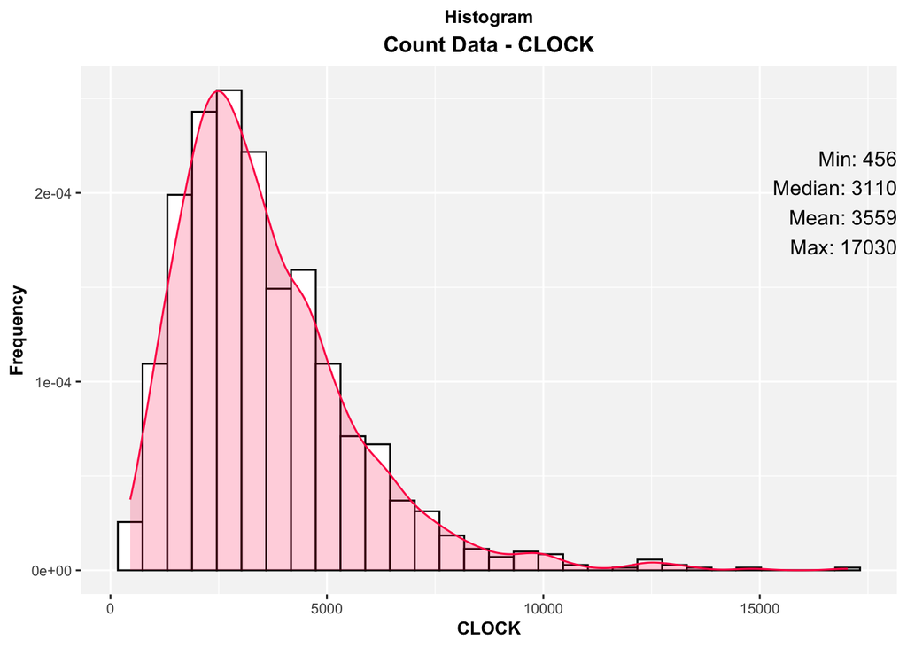

```r
# lets start off with creating our own palette for these visuals
# ive never created my own custom palette before, so lets learn how to

# prompt to Claude Sonnet 4 2025-05-14 (chat.dartmouth.edu):
# in R, how can I create and use my own color palette when creating ggplot2 plots

# response from Claude Sonnet 4 2025-05-14 (chat.dartmouth.edu):
# # Create your palette
# my_palette <- c("#FF6B6B", "#4ECDC4", "#45B7D1", "#96CEB4", "#FFEAA7")
# # Use with discrete data
# ggplot(data, aes(x = variable, fill = category)) +
#   geom_bar() +
#   scale_fill_manual(values = my_palette)

# lets define our variable and pick out some nice looking colors
# also, lets make sure there is enough contrast to show the differences
# in the tissue_types for the scatter plot
# colors were pulled from https://coolors.co/colors
custom_palette <- c("#4cc9f0", "#7209b7", "#ff0054")

# lets create our histogram
hist <- ggplot(gene_metadata, aes(x = !!sym(primary_gene))) +
          # after starting out with a basic histogram, i wanted to add more layers and make it
          # look nicer. I came across https://r-charts.com/ggplot2/, which gave me the idea
          # and examples needed to create the density curve layer.
          # the aes(y = ..density..) is needed to convert the histogram from showing raw counts to
          # showing density, allowing for the density curve to be layered on
          # correctly (Claude Sonnet 4 2025-05-14, chat.dartmouth.edu).
          geom_histogram(bins = 30, aes(y = ..density..), color = "black", fill = "white") +
          # once again, used the example from https://r-charts.com/ggplot2/ to create this
          # density curve layer, then adjust the parameters to better fit my desired style.
          geom_density(lwd = 0.5, color = custom_palette[3], fill = custom_palette[3], alpha = 0.2) +
          # labs() from Week 2 - Lecture notes
          # once again using colnames() to avoid hardcoding the gene name
          labs(
            # histogram plot title
            title = "Histogram",
            ## adding subtitle
            subtitle = paste("Count Data -", primary_gene),
            # x axis label
            x = primary_gene,
            # y axis label
            y = "Frequency"
          ) +
          # theme() from the Week 2 - Lecture notes, text formatting
          ## adding face = "bold", got this idea from
          ## watching Jillian Melbourne's check in video
          theme(
            # default text size
            text = element_text(size = 12),
            # axis title size
            axis.title = element_text(size = 10, face = "bold"),
            # axis text size
            ## adjusted axis text size from 10 to 8
            axis.text = element_text(size = 8),
            # legend title size
            legend.title = element_text(size = 10, face = "bold"),
            # legend text size
            legend.text = element_text(size = 10),
            # plot title size and centering
            plot.title = element_text(size = 10, hjust = 0.5, face = "bold"),
            ## plot subtitle size, centering, and boldface
            plot.subtitle = element_text(size = 12, hjust = 0.5, face = "bold"),
            # another idea from https://r-charts.com/ggplot2/
            # a lighter background (compared to the default gray) helps the
            # colors stand out more
            panel.background = element_rect(fill = "#F5F5F5"),
          )

## lets try adding some summary statistics to the histogram
## i think the min, median, mean, and max would be useful to display

## first, lets determine our min, median, mean, and max and save them to our variables
hist_min <- round(min(gene_metadata[[primary_gene]]))
hist_median <- round(median(gene_metadata[[primary_gene]]))
hist_mean <- round(mean(gene_metadata[[primary_gene]]))
hist_max <- round(max(gene_metadata[[primary_gene]]))

## next, lets use paste0() to create one, cohesive label
## using \n to stack the statistics, so each is on a new line
stats_label <- paste0("Min: ", hist_min,
                      "\nMedian: ", hist_median,
                      "\nMean: ", hist_mean,
                      "\nMax: ", hist_max)

## now, we can use annotate() to add our stats_label
## lets try to position it in the top right, where there is a lot of white space
hist <- hist +
  annotate("text",
           x = Inf,
           y = -Inf,
           label = stats_label,
           hjust = 1.0,
           vjust = -3.3,
           size = 4,
           color = "black")

hist
```

2. Create a Scatter Plot: Select a second gene from the dataset. Create a scatter plot using ggplot2 to compare the count data of the two selected genes.

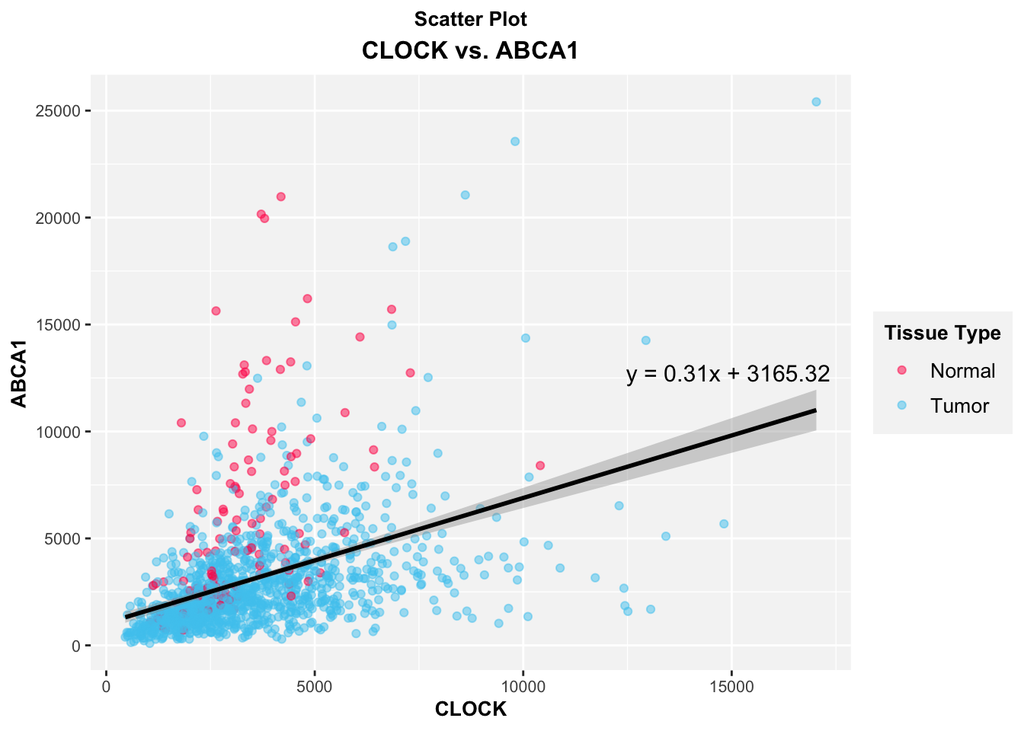

```r
# to fit a linear model from the Week 3 - Lecture notes
# fit a linear model based on our two genes, to use in the scatter plot
model <- lm(gene_metadata[,1] ~ gene_metadata[,2], data = gene_metadata)
# define our coefficients
coefficients <- coef(model)
# define our y intercept
intercept <- coefficients[1]
# define our slop
slope <- coefficients[2]
# create our label to display on the plot
eq_label <- paste0("y = ", round(slope, 2), "x + ", round(intercept, 2))

# next, lets create our scatter plot
# basic ggplot scatter plot, decided to add color = tissue_type group to add more
# information to the plot
# also, decided to add the regression line from Week 3 - Lecture notes
scatter <- ggplot(gene_metadata, aes(x = !!sym(primary_gene), y = !!sym(secondary_gene), color = tissue_type)) +
            # geom_point() for scatter plot,
            # alpha = 0.5 helps to better show the distinction between the two tissue types
            geom_point(alpha = 0.5) +
            # geom_smooth() from Week 3 - Lecture notes for the linear model
            ## making the lm line and equation label black
            ## black makes the label and line pop more, and looks cleaner with the now-bold titles
            geom_smooth(method = "lm", color = "black") +
            # from Week 3 - Lecture notes
            # use the eq_label we built above and display it on the plot
            # use hjust and vjust to place the label in the top right corner, where there
            # is a lot of whitespace
            ## adjusting text size to make it slightly smaller
            annotate("text", x = Inf, y = -Inf, label = eq_label, hjust = 1.1, vjust = -17.5, size = 4, color = "black") +
            # scale_color_manual() to use my custom color palette above
            scale_color_manual(values = c(custom_palette[3], custom_palette[1])) +
            # labs() from Week 2 - Lecture notes
            # using colnames() to avoid hardcoding the gene name
            labs(
              # scatter plot title
              title = "Scatter Plot",
              ## adding subtitle
              subtitle = paste(primary_gene, "vs.", secondary_gene),
              # x axis label
              x = primary_gene,
              # y axis label
              y = secondary_gene,
              # legend label
              color = "Tissue Type"
            ) +
            # theme() from the Week 2 - Lecture notes, text formatting
            ## adding face = "bold", got this idea from
            ## watching Jillian Melbourne's check in video
            theme(
              # default text size
              text = element_text(size = 12),
              # axis title size
              axis.title = element_text(size = 10, face = "bold"),
              # axis text size
              ## adjusted axis text size from 10 to 8
              axis.text = element_text(size = 8),
              # legend title size
              legend.title = element_text(size = 10, face = "bold"),
              # legend text size
              legend.text = element_text(size = 10),
              ## adding a light gray background to the legend
              ## groups the title and types nicely, idea from https://r-charts.com/ggplot2/legend/
              legend.background = element_rect(fill = "#F5F5F5"),
              # plot title size and centering
              plot.title = element_text(size = 10, hjust = 0.5, face = "bold"),
              ## plot subtitle size, centering, and boldface
              plot.subtitle = element_text(size = 12, hjust = 0.5, face = "bold"),
              # same as above, the idea is from https://r-charts.com/ggplot2/
              # a lighter background (compared to the default gray) helps the
              # colors stand out more
              panel.background = element_rect(fill = "#F5F5F5")
            )

scatter
```

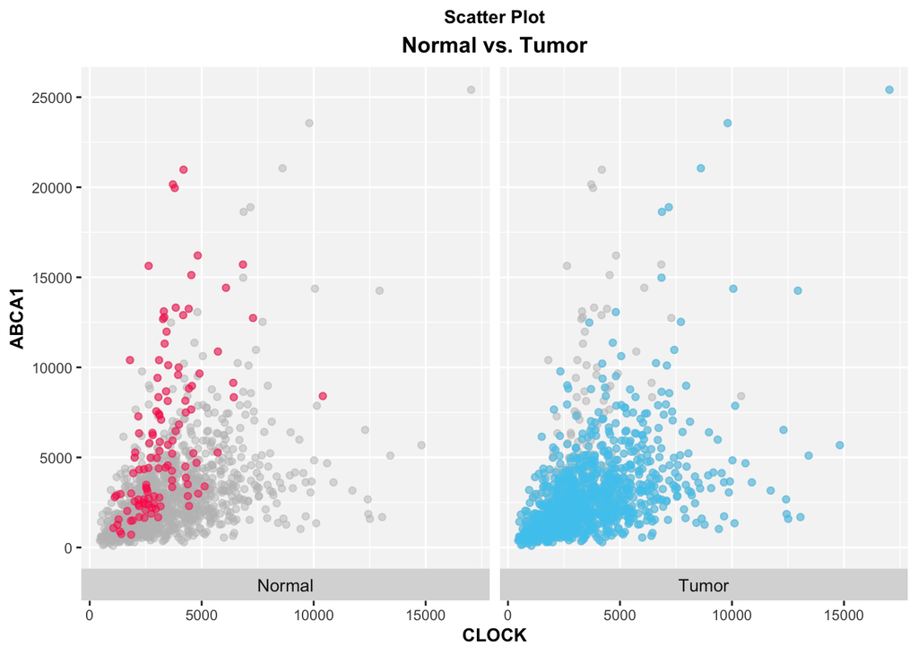

```r
## looking at the plot, it would be interesting to plot the two tissue types separately
## using the example from https://r-charts.com/ggplot2/facets/, it looks like i can
## plot the two types seperately, but display them side by side using facet_wrap()

## most of our plot can be resued from above, with a few minor tweaks
scatter_compare <- ggplot(gene_metadata, aes(x = !!sym(primary_gene), y = !!sym(secondary_gene), color = tissue_type)) +
            ## here we will need two geom_point()
            ## one for the focused group
            ## the second for a faded gray background of the total points
            ## first, lets add the faded gray background of the total data
            ## example is based on  https://r-charts.com/ggplot2/facets/
            ## tissue_type = NULL is plotting the total points in gray (no grouping)
            ## this gives a nice comparison for the focused tissue type
            geom_point(alpha = 0.5, data = transform(gene_metadata, tissue_type = NULL), color = "grey") +
            ## now, lets add our focused tissue type
            ## show.legend = FALSE, since it doesnt add any useful information here
            geom_point(alpha = 0.5, show.legend = FALSE) +
            ## keeping our same color palette for consistency
            scale_color_manual(values = c(custom_palette[3], custom_palette[1])) +
            ## now we use facet_wrap(), this is what will make seperate plots for each of
            ## groups / tissue types
            ## grouped on ~tissue_type, strip.position places the group label on the bottom
            facet_wrap(~tissue_type, strip.position = "bottom") +
            ## lets add some labels, keeping consistent with the formatting
            labs(
              ## scatter plot title
              title = "Scatter Plot",
              ## adding subtitle
              subtitle = "Normal vs. Tumor",
              ## x axis label
              x = primary_gene,
              ## y axis label
              y = secondary_gene,
              ## legend label
              color = "Tissue Type"
            ) +
            ## theme() from the Week 2 - Lecture notes, text formatting
            theme(
              ## default text size
              text = element_text(size = 12),
              ## axis title size
              axis.title = element_text(size = 10, face = "bold"),
              ## axis text size
              axis.text = element_text(size = 8),
              ## plot title size and centering
              plot.title = element_text(size = 10, hjust = 0.5, face = "bold"),
              ## plot subtitle size, centering, and boldface
              plot.subtitle = element_text(size = 12, hjust = 0.5, face = "bold"),
              ## same as above, the idea is from https://r-charts.com/ggplot2/
              ## a lighter background (compared to the default gray) helps the
              ## colors stand out more
              panel.background = element_rect(fill = "#F5F5F5"),
            )

scatter_compare
```

3. Create a Violin Plot: Select one covariate from your metadata. Using the count data from the first gene and the selected covariate, generate a violin plot that illustrates the distribution of count data based on the covariate. For example, if you choose “primary_diagnosis”, your plot should display a violin plot for each level in “primary_diagnosis”.

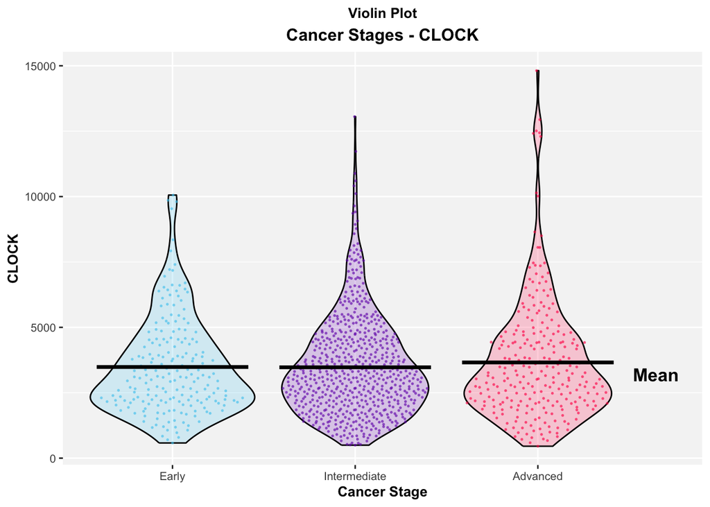

```r
# originally, I wanted to use the ajcc_pathologic_stage column as the covariate
# but after looking at the data:
# Stage 0    Stage I   Stage IA   Stage IB   Stage II  Stage IIA
# 4         98         93          6          7        374
# Stage IIB Stage IIIA Stage IIIB Stage IIIC   Stage IV    Stage X
# 267        155         27         62         20          7
# some stages have significantly more samples than others, so lets group the stages
# into broader categories, such as Early, Intermediate, and Advanced

# i am not sure how i can do this, so lets ask claude

# prompt to Claude Sonnet 4 2025-05-14 (chat.dartmouth.edu):
# how can I create a new column that contains more broader categories, such as Early,
# Intermediate, and Advanced, for the following stages in the ajcc_pathologic column:
# Stage 0 Stage I Stage IA Stage IB Stage II Stage IIA
# Stage IIB Stage IIIA Stage IIIB Stage IIIC Stage IV Stage X

# response from Claude Sonnet 4 2025-05-14 (chat.dartmouth.edu):
# df$stage_broad <- "Advanced"  # Set default
# df$stage_broad[df$ajcc_pathologic %in% c("Stage 0", "Stage I", "Stage IA", "Stage IB")] <- "Early"
# df$stage_broad[df$ajcc_pathologic %in% c("Stage II", "Stage IIA", "Stage IIB")] <- "Intermediate"

# i dont like the idea of setting the default to advanced, but the rest of the syntax is helpful
# lets try this with our specific data frames and columns
gene_metadata$cancer_stage[gene_metadata$ajcc_pathologic_stage %in% c("Stage 0", "Stage I", "Stage IA", "Stage IB")] <- "Early"
gene_metadata$cancer_stage[gene_metadata$ajcc_pathologic_stage %in% c("Stage II", "Stage IIA", "Stage IIB")] <- "Intermediate"
gene_metadata$cancer_stage[gene_metadata$ajcc_pathologic_stage %in% c("Stage IIIA", "Stage IIIB", "Stage IIIC", "Stage IV")] <- "Advanced"

# updating this new column to be a factor, so that i can display the levels in order Early -> Advanced
gene_metadata$cancer_stage <- factor(gene_metadata$cancer_stage, levels = c("Early", "Intermediate", "Advanced"), ordered = TRUE)

# the violin plot was also displaying the NA data, lets clean the data and remove the NA
# since displaying the NA data is not useful here
gene_metadata_clean <- gene_metadata[!is.na(gene_metadata$cancer_stage),]

# lets create our violin plot, using our new cancer_stage column
violin <- ggplot(gene_metadata_clean, aes(x = cancer_stage, y = !!sym(primary_gene), fill = cancer_stage, color = cancer_stage)) +
            # the violin plot was looking plain, so i decided to add additional information
            # the idea and examples to add the quantiles
            # was from https://r-charts.com/distribution/violin-plot-group-ggplot2
            ## removed the quantiles, and replaced it with a bold line for the median
            geom_violin(alpha = 0.2, color = "black") +
            ## using ggbeeswarm and geom_quasirandom to add plot points to the violin plot
            ## cex adjusts the point size, making the points small to avoid be too distracting
            ## referenced ggbeeswarm documentation for help https://github.com/eclarke/ggbeeswarm
            geom_quasirandom(alpha = 0.5, cex = 0.3) +
            ## using stat_summary to add a bold median line
            ## based on an example from https://r-charts.com/distribution/violin-plot-mean-ggplot2/
            stat_summary(fun = "mean", geom = "crossbar", width = 0.83, color = "black") +
            # using scale_y_log10() to reduce the impact of outliers on the visualizations
            ## after reflecting on feedback from the comments, i do not think scale_y_log10
            ## is necessary here, if anything it distorts some useful information about the outliers
            ## scale_y_log10() +
            # scale_fill_manual() to use my custom color palette above
            scale_fill_manual(values = custom_palette) +
            ## scale_color_manual() to color the beeswarm plot points
            scale_color_manual(values = custom_palette) +
            # using colnames() to avoid hardcoding the gene name
            labs(
              # violin plot title
              title = "Violin Plot",
              ## adding subtitle
              subtitle = paste("Cancer Stages -", primary_gene),
              # x axis label
              x = "Cancer Stage",
              # y axis label
              y = primary_gene,
              # legend label
              fill = "Cancer Stage",
              # legend label
              color = "Cancer Stage"
            ) +
            # theme() from the Week 2 - Lecture notes, text formatting
            ## adding face = "bold", got this idea from
            ## watching Jillian Melbourne's check in video
            theme(
              # default text size
              text = element_text(size = 12),
              # axis title size
              axis.title = element_text(size = 10, face = "bold"),
              # axis text size
              ## adjusted axis text size from 10 to 8
              axis.text = element_text(size = 8),
              # another idea from Jillian Melbourne's video, removing the
              # legend due to redundancy, doesnt add any useful information
              legend.position = "none",
              ## adding a light gray background to the legend
              ## groups the title and types nicely, idea from https://r-charts.com/ggplot2/legend/
              legend.background = element_rect(fill = "#F5F5F5"),
              # plot title size and centering
              plot.title = element_text(size = 10, hjust = 0.5, face = "bold"),
              ## plot subtitle size, centering, and boldface
              plot.subtitle = element_text(size = 12, hjust = 0.5, face = "bold"),
              # same as previous two above, the idea is from https://r-charts.com/ggplot2/
              # a lighter background (compared to the default gray) helps the
              # colors stand out more
              panel.background = element_rect(fill = "#F5F5F5"),
            ) +
            ### Jillian brought up a good point in the comments, i should add a legend
            ### or identifier for the mean line
            ### lets add it to the right of the lines, since there are all relatively similar height
            ### i think i can just put it inline and it will be clear
            ### lets use the scale_x_discrete() we learned during the new bar chart to extend the x axis to make room
            scale_x_discrete(expand = expansion(mult = c(0.3, 0.45))) +
            ### now lets add an annotation for the Mean label and position it on the right
            annotate("text", x = Inf, y = -Inf, label = "Mean", hjust = 1.50, vjust = -6.5, size = 4.5, color = "black", fontface = "bold")

violin
```

4. Heatmap Analysis:
   1. Select 10 genes: Choose a set of 10 different genes from the count matrix for your heatmap.
   2. Generate a Heatmap: Use the ComplexHeatmap package in R to create a heatmap of the count data for the selected genes.
   3. Add an Annotation Bar: Include an annotation bar reflecting your chosen covariate for further context and interpretation of the data.